# HSC Survey Results

# German Bank Survey # 2 Results from 20/08/2023

## Survey Details

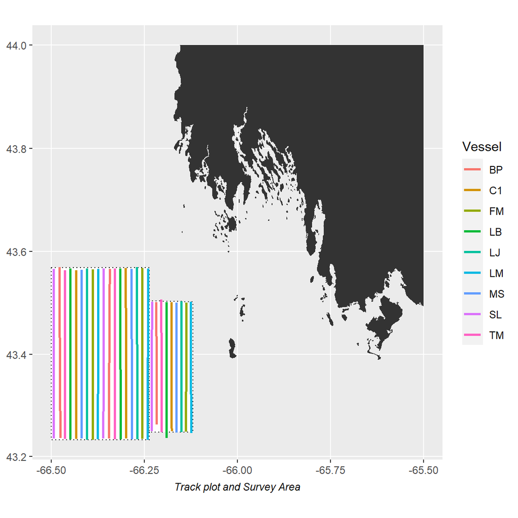

9 commercial purse seiners conducted this fishing survey on 20/08/2023 starting at 20:30:00.

All vessels ran two transects in the German Bank box and one transect in the Seal Island Box.

There was a plankton tow and replicate conducted and CTD cast by Lady Melissa.

A total of 1,255 tags were applied during the survey over 5 event(s) from 2023-08-21 to 2023-08-23 from 3 vessel(s).

### Acoustic Equipment

Each vessel was equipped with a Simrad ES38-18/200-18C combi (2-in-1) transducer prior to the survey that contains a 38kHz split beam and 200 kHz single beam transducer. Data was logged to the computer hard-drive for post-processing. All participating boats were calibrated on 38kHz before the survey.

## Survey Results

### Main Results

The results are subject to change as DFO will re-evaluate data editing, area estimation and apply a target strength.

**Preliminary biomass prediction for German Bank using standardized parallel transects is 4,930mt, and with turnover applied 4,406mt. The preliminary biomass estimate for Seal Island is 1,918mt.**

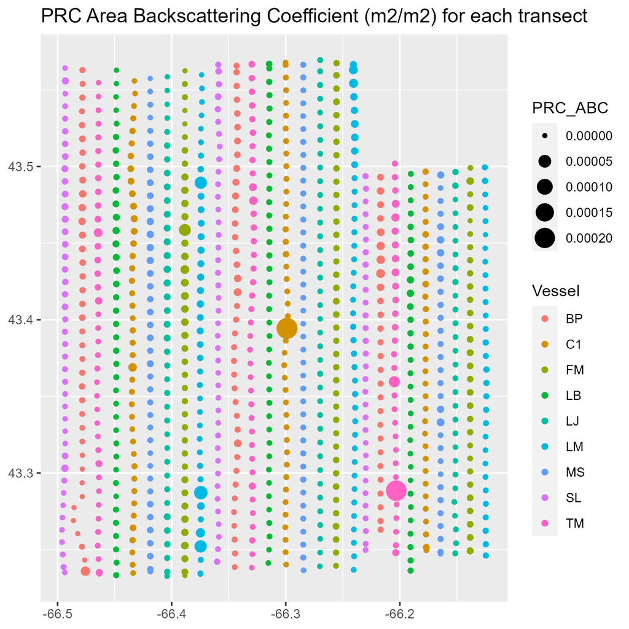

### Transect Details

Table 1: Transect Details

| Vessel | Transect # | Date/Time Start | Date/Time End | Start Lon | Start Lat | End Lon | End Lat | Location | Distance (km) | Speed |
| --- | --- | --- | --- | --- | --- | --- | --- | --- | --- | --- |
| BP | T01 | 2023-08-20 21:16:34 | 2023-08-20 23:43:34 | -66.478 | 43.569 | -66.476 | 43.236 | GB | 37.55 | 8.28 |
| BP | T02 | 2023-08-21 00:22:42 | 2023-08-21 02:36:47 | -66.346 | 43.235 | -66.343 | 43.566 | GB | 36.86 | 8.91 |
| BP | T03 | 2023-08-21 03:24:35 | 2023-08-21 05:10:49 | -66.218 | 43.501 | -66.217 | 43.263 | GB | 26.53 | 8.09 |
| C1 | T01 | 2023-08-20 20:32:18 | 2023-08-20 22:50:27 | -66.434 | 43.563 | -66.434 | 43.235 | GB | 40.58 | 9.52 |
| C1 | T02 | 2023-08-20 23:29:08 | 2023-08-21 01:51:31 | -66.299 | 43.235 | -66.300 | 43.568 | GB | 40.85 | 9.29 |
| C1 | T03 | 2023-08-21 02:35:03 | 2023-08-21 04:25:12 | -66.178 | 43.501 | -66.177 | 43.250 | GB | 30.82 | 9.06 |
| FM | T01 | 2023-08-21 21:24:25 | 2023-08-21 23:45:16 | -66.388 | 43.565 | -66.388 | 43.233 | GB | 38.59 | 8.88 |
| FM | T02 | 2023-08-22 00:24:19 | 2023-08-22 02:40:45 | -66.256 | 43.235 | -66.256 | 43.567 | GB | 38.47 | 9.14 |
| FM | T03 | 2023-08-22 03:27:39 | 2023-08-22 05:16:04 | -66.138 | 43.500 | -66.138 | 43.249 | GB | 29.16 | 8.72 |
| LB | T01 | 2023-08-20 20:21:14 | 2023-08-20 22:42:59 | -66.448 | 43.567 | -66.449 | 43.233 | GB | 38.38 | 8.77 |
| LB | T02 | 2023-08-20 23:29:31 | 2023-08-21 01:47:50 | -66.314 | 43.234 | -66.315 | 43.567 | GB | 38.20 | 8.95 |
| LB | T03 | 2023-08-21 02:39:44 | 2023-08-21 04:34:49 | -66.191 | 43.501 | -66.191 | 43.236 | GB | 30.47 | 8.58 |
| LJ | T01 | 2023-08-20 20:24:29 | 2023-08-20 22:47:09 | -66.405 | 43.567 | -66.404 | 43.233 | GB | 37.25 | 8.46 |
| LJ | T02 | 2023-08-20 23:27:03 | 2023-08-21 01:45:09 | -66.270 | 43.234 | -66.270 | 43.569 | GB | 37.39 | 8.77 |
| LJ | T03 | 2023-08-21 02:30:37 | 2023-08-21 04:20:14 | -66.151 | 43.503 | -66.151 | 43.248 | GB | 28.52 | 8.43 |
| LM | T01 | 2023-08-20 20:16:09 | 2023-08-20 22:40:13 | -66.374 | 43.566 | -66.375 | 43.234 | GB | 37.80 | 8.50 |
| LM | T02 | 2023-08-20 23:19:39 | 2023-08-21 01:35:08 | -66.241 | 43.233 | -66.241 | 43.567 | GB | 37.82 | 9.04 |
| LM | T03 | 2023-08-21 02:17:49 | 2023-08-21 04:10:12 | -66.126 | 43.502 | -66.125 | 43.246 | GB | 29.17 | 8.41 |
| MS | T01 | 2023-08-20 20:29:09 | 2023-08-20 22:50:30 | -66.419 | 43.564 | -66.419 | 43.236 | GB | 38.98 | 8.93 |
| MS | T02 | 2023-08-20 23:36:48 | 2023-08-21 01:54:58 | -66.284 | 43.234 | -66.285 | 43.566 | GB | 39.31 | 9.22 |
| MS | T03 | 2023-08-21 02:48:41 | 2023-08-21 04:37:00 | -66.164 | 43.500 | -66.164 | 43.247 | GB | 29.81 | 8.92 |
| SL | T01 | 2023-08-20 21:22:56 | 2023-08-20 23:50:31 | -66.493 | 43.566 | -66.494 | 43.235 | GB | 40.62 | 8.92 |
| SL | T02 | 2023-08-21 00:30:49 | 2023-08-21 02:53:21 | -66.360 | 43.235 | -66.359 | 43.566 | GB | 40.38 | 9.18 |
| SL | T03 | 2023-08-21 03:37:21 | 2023-08-21 05:25:43 | -66.230 | 43.502 | -66.230 | 43.250 | GB | 30.46 | 9.11 |
| TM | T01 | 2023-08-20 20:27:24 | 2023-08-20 22:51:04 | -66.464 | 43.563 | -66.464 | 43.234 | GB | 37.05 | 8.36 |
| TM | T02 | 2023-08-20 23:33:18 | 2023-08-21 01:44:34 | -66.330 | 43.234 | -66.330 | 43.567 | GB | 37.58 | 9.28 |
| TM | T03 | 2023-08-21 02:31:11 | 2023-08-21 04:23:30 | -66.205 | 43.507 | -66.204 | 43.248 | GB | 29.11 | 8.40 |

### Survey Summary

Table 2: Acoustic Survey Results

| Vessel | Transect No. | Target Strength (db/kg) | Mean Sa (/m2) | Biomass Density (kg/m2) |
| --- | --- | --- | --- | --- |
| TM | T03 | -35.5 | -50.076 | 0.035 |
| C1 | T02 | -35.5 | -52.126 | 0.022 |
| LM | T01 | -35.5 | -52.485 | 0.020 |
| FM | T01 | -35.5 | -54.489 | 0.013 |
| BP | T03 | -35.5 | -56.348 | 0.008 |
| LM | T02 | -35.5 | -57.421 | 0.006 |
| FM | T03 | -35.5 | -58.250 | 0.005 |
| BP | T01 | -35.5 | -58.296 | 0.005 |
| BP | T02 | -35.5 | -58.455 | 0.005 |
| MS | T03 | -35.5 | -58.577 | 0.005 |
| MS | T01 | -35.5 | -58.661 | 0.005 |
| FM | T02 | -35.5 | -58.669 | 0.005 |
| LJ | T01 | -35.5 | -58.748 | 0.005 |
| C1 | T01 | -35.5 | -59.354 | 0.004 |
| TM | T02 | -35.5 | -59.470 | 0.004 |
| TM | T01 | -35.5 | -59.713 | 0.004 |
| SL | T01 | -35.5 | -59.781 | 0.004 |
| LB | T01 | -35.5 | -59.966 | 0.004 |
| LB | T03 | -35.5 | -60.331 | 0.003 |
| C1 | T03 | -35.5 | -61.597 | 0.002 |
| LM | T03 | -35.5 | -62.472 | 0.002 |
| LB | T02 | -35.5 | -62.986 | 0.002 |
| SL | T03 | -35.5 | -63.241 | 0.002 |
| SL | T02 | -35.5 | -63.661 | 0.002 |
| MS | T02 | -35.5 | -63.834 | 0.001 |
| LJ | T03 | -35.5 | -63.882 | 0.001 |
| LJ | T02 | -35.5 | -63.992 | 0.001 |

Note:  
Transects are listed from greatest to least backscatter.

Table 3: Survey Summary Table

| Layer | Target Strength | Area (km2) | Mean Sa | Density (kg/m2) | Biomass (tons) | Percent Area | Percent Biomass | Standard Error (tons) | Standard Error (%) |
| --- | --- | --- | --- | --- | --- | --- | --- | --- | --- |
| German Bank | -35.5 | 796 | -57.5803 | 0.0062 | 4,930.454 | NA | NA | 1,111.54 | 22.54 |
| Seal Island | -35.5 | 272 | -57.0176 | 0.0071 | 1,917.847 | NA | NA | 963.37 | 50.23 |
| School Survey | NA | NA | NA | NA | NA | NA | NA | NA | NA |

### Greatest Biomass Densities

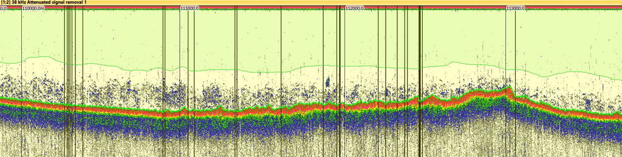

A snip from the transect with the greatest biomass density (kg/m2)

The single point with the largest biomass density (kg/m2) was recorded by **C1**, at the following location:

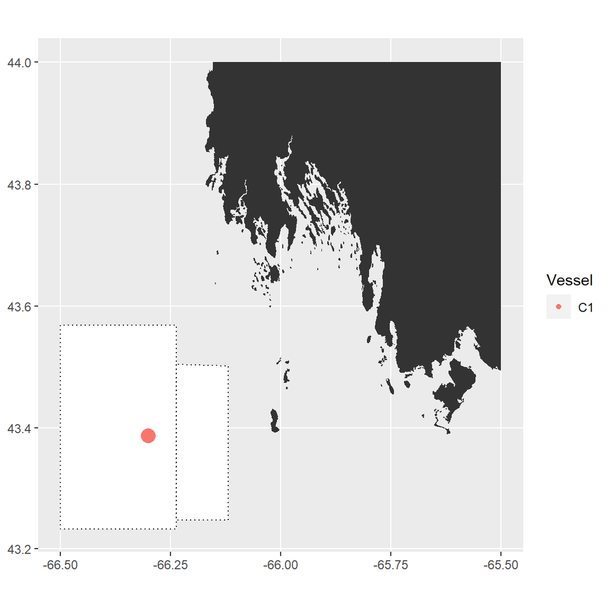

The transect with the greatest average biomass density (kg/m2) was recorded by **TM**, at the following location:

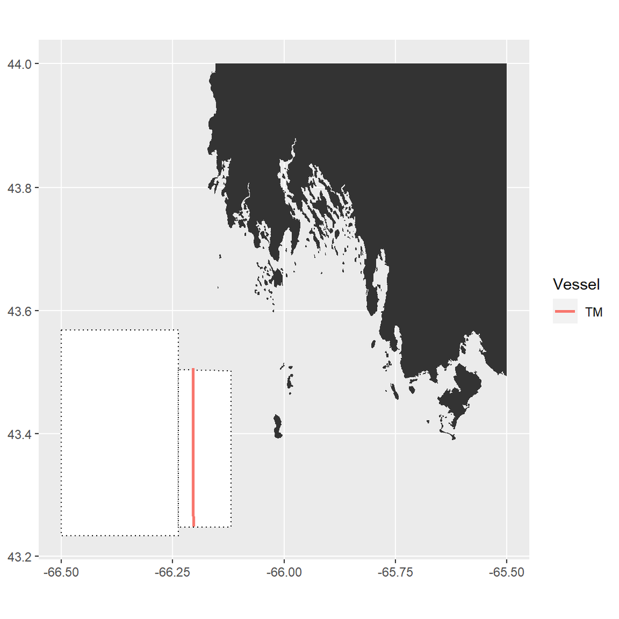

### Annual Summaries

Table 4: Annual Comparison Table

| Ground | Survey Number | Current Year Survey Date | Current Year HSC Estimate | Current Year HSC Turnover Adjusted | Previous Year Survey Date | Previous Year HSC Estimate | Previous Year HSC Turnover Adjusted | Previous Year DFO Estimate | Previous Year DFO Turnover Adjusted |
| --- | --- | --- | --- | --- | --- | --- | --- | --- | --- |
| German Bank | 1 | 2023-08-06 | 2,686.514 | NA | 2022-08-14 | 16,285 | 16,285 | 22,081 | 22,081 |
| Seal Island | 1 | 2023-08-06 | 1,205.361 | NA | 2022-08-14 | 2,598 | 2,598 | 2,086 | 2,086 |
| German Bank | 2 | 2023-08-20 | 4,930.454 | 4,406.486 | 2022-08-28 | 7,472 | 4,296 | 11,699 | 7,393 |
| Seal Island | 2 | 2023-08-20 | 1,917.847 | NA | 2022-08-28 | 1,048 | 1,048 | 570 | 570 |
| German Bank | 3 | 2023-09-03 | 9,959.441 | 8,377.032 | 2022-09-11 | 12,507 | 10,464 | 11,902 | 8,826 |
| Seal Island | 3 | 2023-09-03 | 2,062.584 | NA | 2022-09-11 | 6,941 | 6,941 | 6,392 | 6,392 |
| German Bank | 4 | NA | NA | NA | 2022-09-25 | 15,924 | 13,216 | 12,503 | 9,761 |
| German Bank | 5 | NA | NA | NA | 2022-10-10 | 19,539 | 16,337 | 20,247 | 17,675 |
| German Bank | 6 | NA | NA | NA | 2022-10-23 | 13,399 | 8,684 | 15,565 | 10,823 |
| Seal Island | 4 | NA | NA | NA | 2022-09-25 | 4,634 | 4,634 | 3,732 | 3,732 |
| Seal Island | 5 | NA | NA | NA | 2022-10-10 | 5,243 | 5,243 | 5,604 | 5,604 |
| Seal Island | 6 | NA | NA | NA | 2022-10-23 | 2,944 | 2,944 | 3,260 | 3,260 |

Table 5: Annual Summary Table

| Year | Ground | HSC Estimate | HSC Turnover Adjusted | DFO Estimate | DFO Turnover Adjusted |
| --- | --- | --- | --- | --- | --- |
| 2022 | German Bank | 85,126.000 | 69,282 | 93,997 | 76,559 |
| 2022 | Seal Island | 23,408.000 | 23,408 | 21,644 | 21,644 |
| 2023 | German Bank | 17,576.410 | NA | NA | NA |
| 2023 | Seal Island | 5,185.792 | NA | NA | NA |

## Tagging, Plankton, and CTD Data

### Tag Data

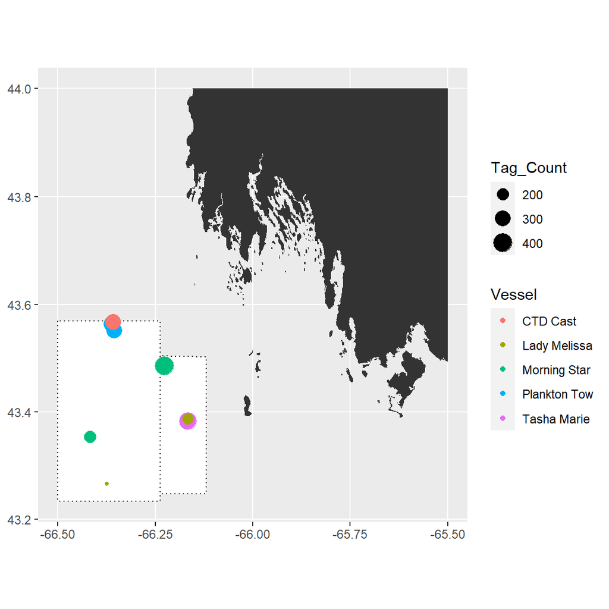

| Vessel | Tags |
| --- | --- |
| Lady Melissa | 310 |
| Morning Star | 600 |
| Tasha Marie | 345 |

### Plankton Data

#### Tow Summary Table

|  | Tow 1 | Tow 2 |
| --- | --- | --- |
| **Base Details** |  |  |
| Vessel | Lady Melissa | Lady Melissa |
| Set Number | GB2023-03 | GB2023-04 |
| Ground | GB | GB |
| Date | 20/08/2023 | 20/08/2023 |
| Wind Direction (km/h) | W | W |
| Swell (m) | 1 | 1 |
| Air Temp (c) | 15 | 16 |
| **Tow Details** |  |  |
| Tow Start | 19:31:00 | 19:51:00 |
| Tow End | 19:41:00 | 20:01:00 |
| Start Lat | 43.55167 | 43.56333 |
| End Lat | 43.55167 | 43.57667 |
| Start Lon | -66.35500 | -66.36167 |
| End Lon | -66.35333 | -66.35833 |
| Avg Tow Depth (m) | 4.094902 | 1.838788 |
| Speed | 5.8 | 5.8 |
| Heading | 180 | 0 |
| Tide Direction | with | against |
| **Other Data Collection** |  |  |
| Flow Start | 709734 | 766003 |
| Flow End | 766003 | 829697 |
| No. Revolutions | 56269 | 63694 |
| Distance (m) | 1512.117 | 1711.649 |
| Volume | 4750.315 | 5377.145 |
| Secchi Disappear (m) | 7 | 7 |
| Secchi Reappear (m) | 6 | 6 |

#### Tow Depth Profiles

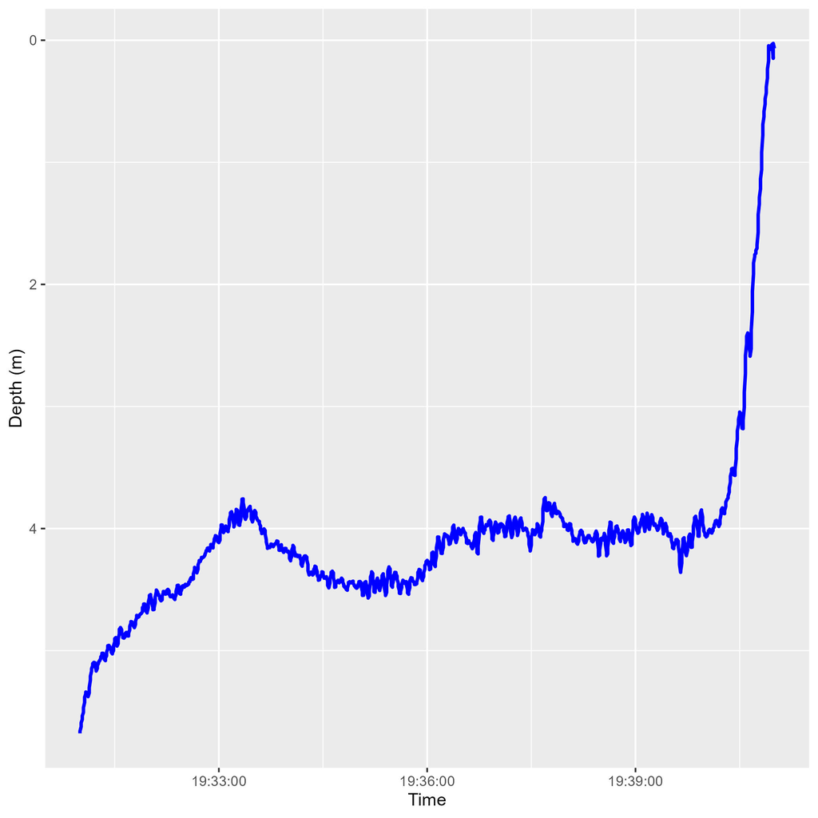

Plankton tow depth profile #1

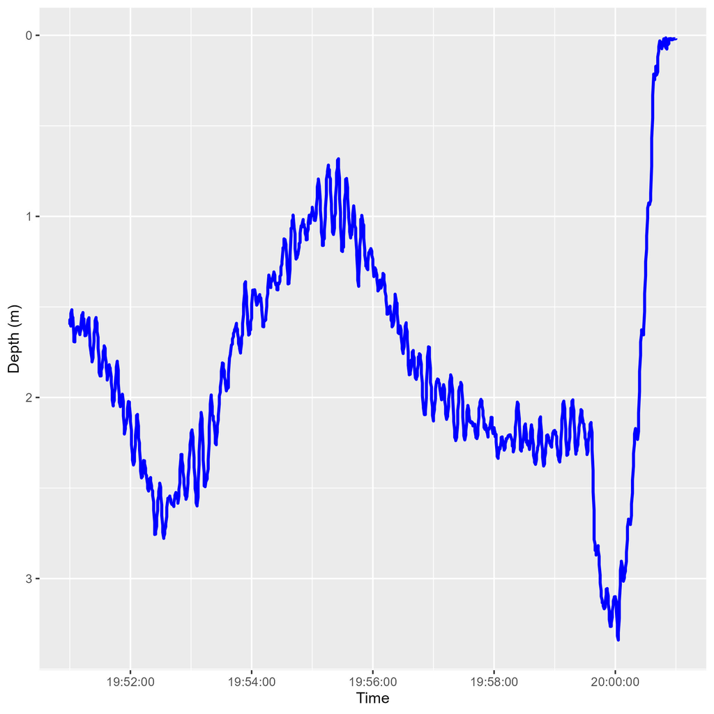

Plankton tow depth profile #2

The first tow is GB2023-03, which was with the tide and had an average depth of 4.0949022m. The second tow is GB2023-04, which was against the tide and had an average depth of 1.8387878m.

#### Captured plankton

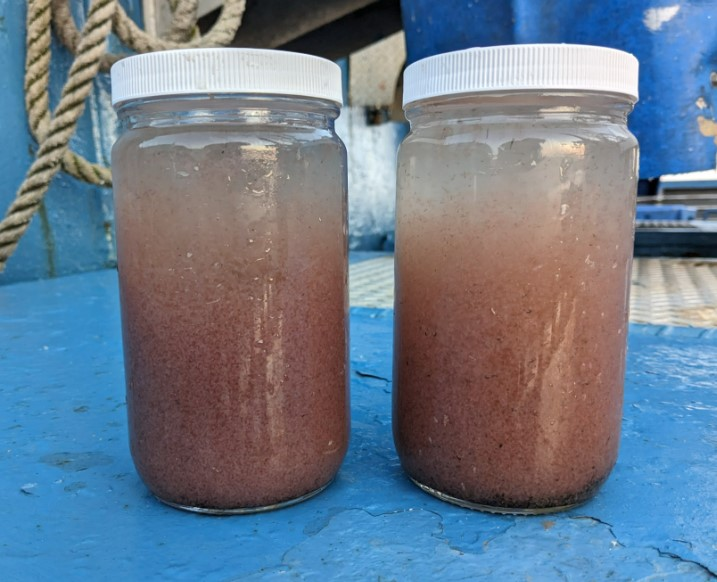

Captured plankton from the surface tows

### CTD Data

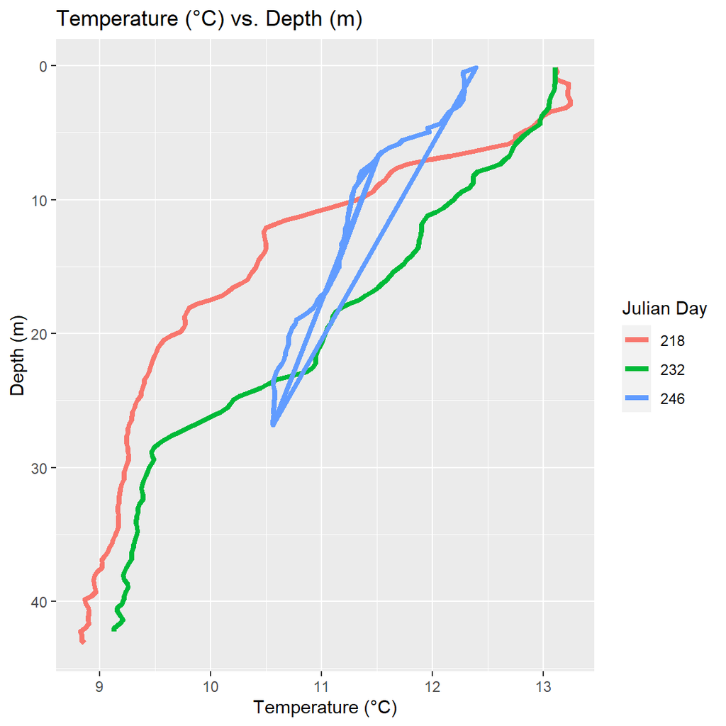

CTD depth profiles for all 2023 German Bank surveys so far.

#### Sea surface temperatures

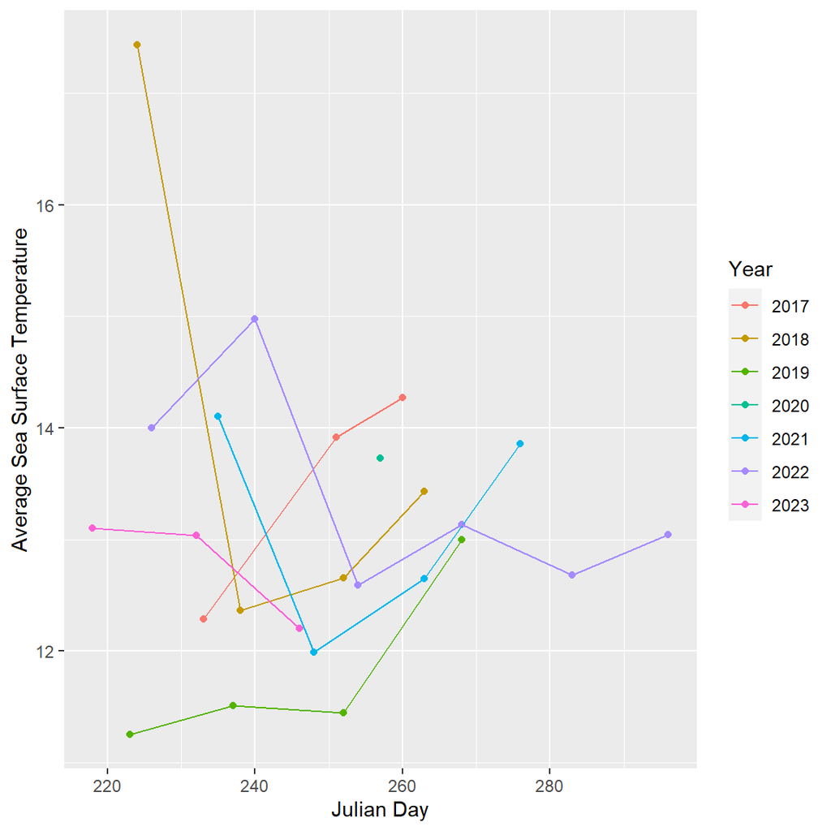

Annual average sea surface temperatures (SST) for German Bank.

## Vessel Performance

### Speed

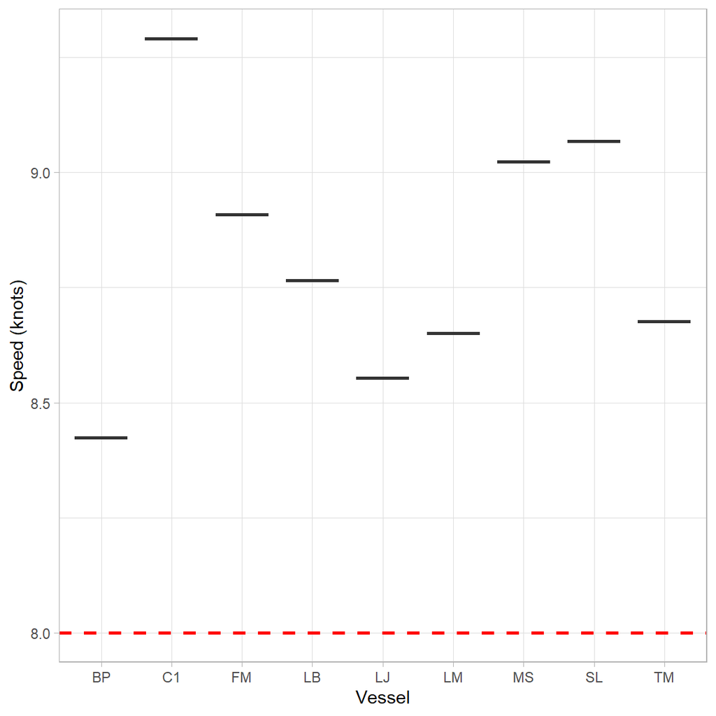

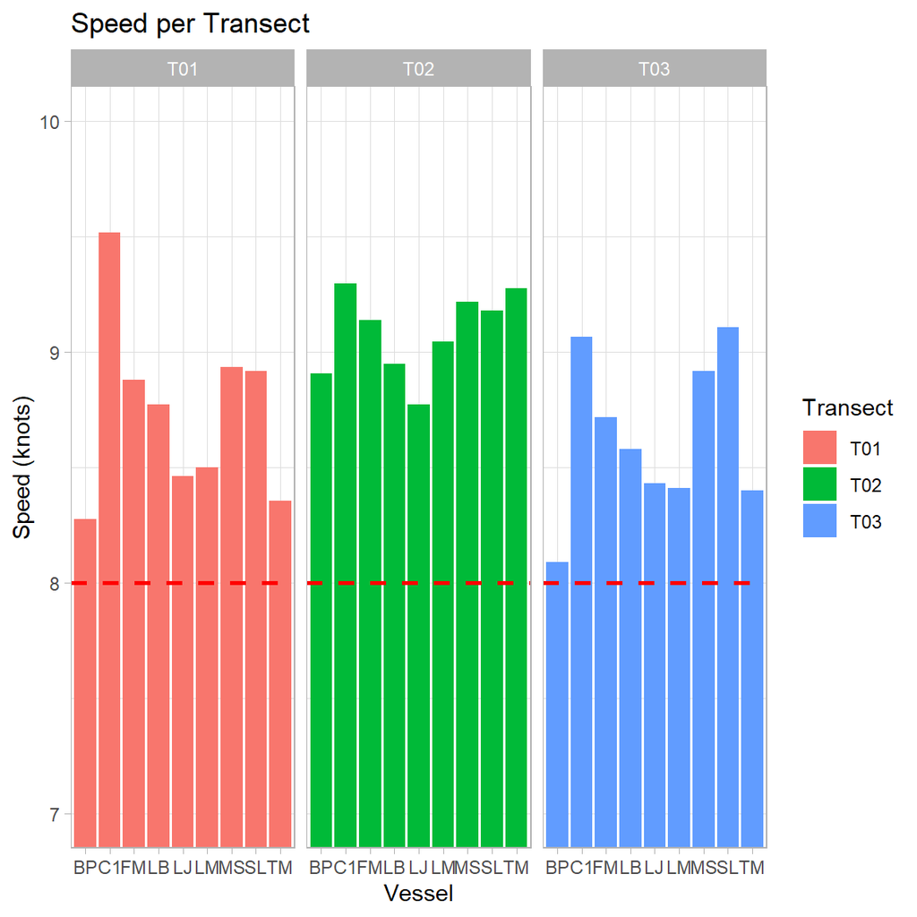

Average vessel speed was 8.82. This is above the 8 knot requirement; vessels are urged to slow down to prevent backscatter noise from interfering with the acoustic data.

### Distance

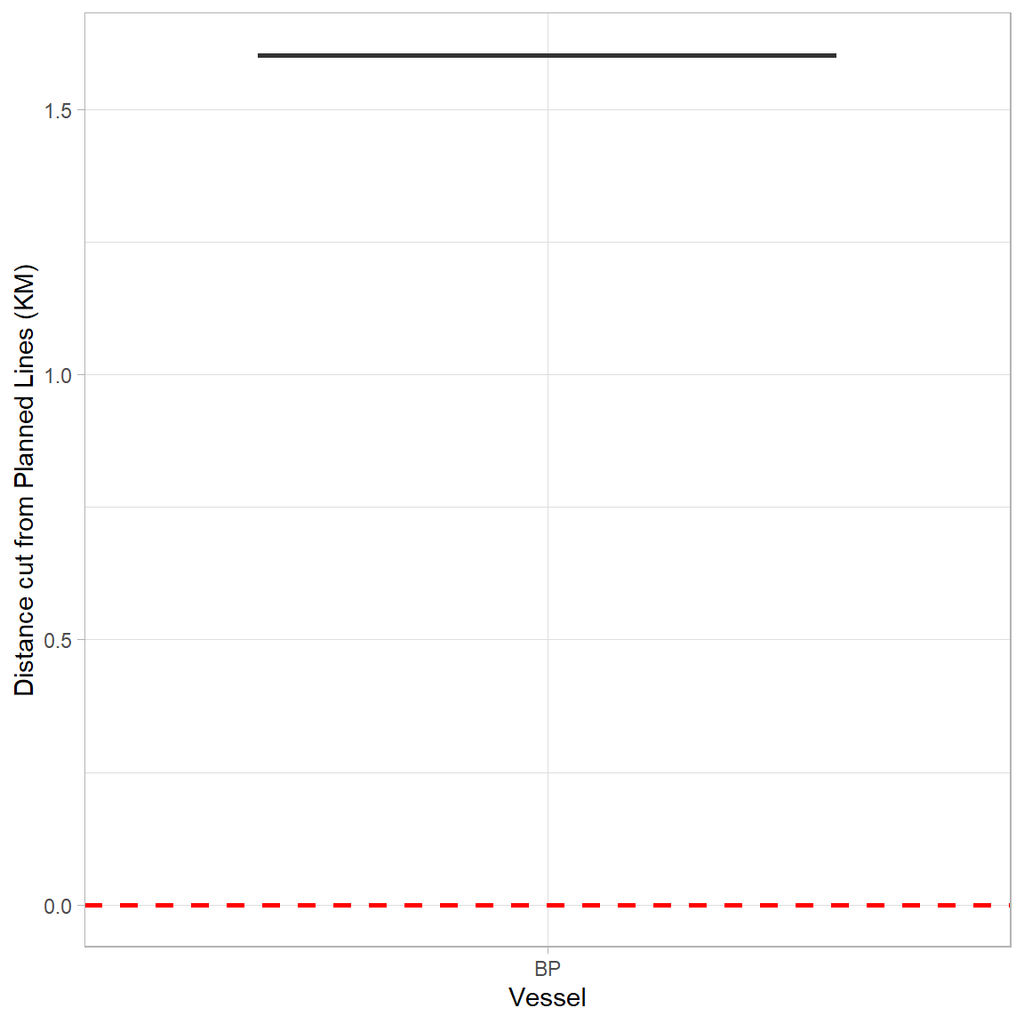